# Analysis of agate beads from KWL-I site

## Introduction

In this analysis, I examine 271 agate beads from Kiwulan site, which was excavated in 2001. The total number of agate beads is 783. The samples selected are the beads with clear archaeological context from household area, burials, and midden. Agate beads can be classified to main 8 types according to their shape, size, and texture. Among these types, hexagonal shaped beads is the main category with the total number of 140.

## Analysis

### Size distributions by bead shape

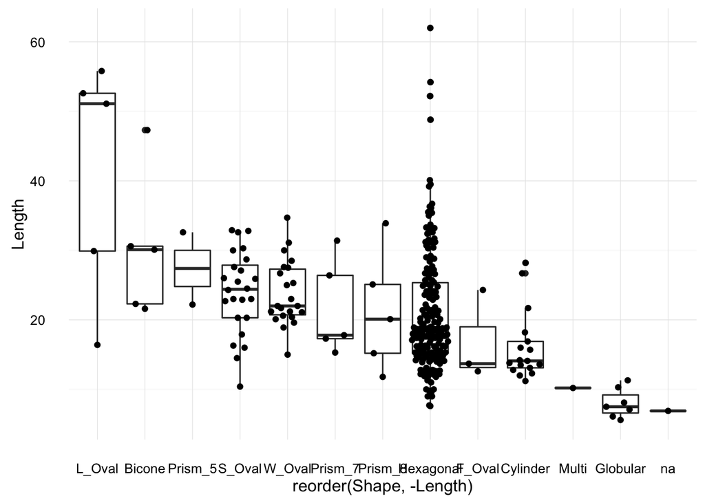

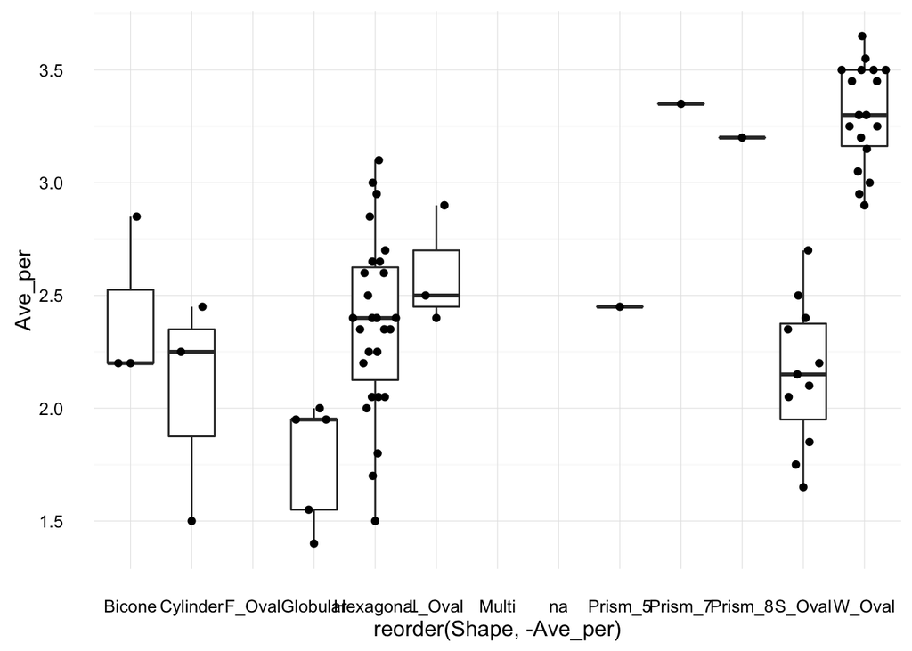

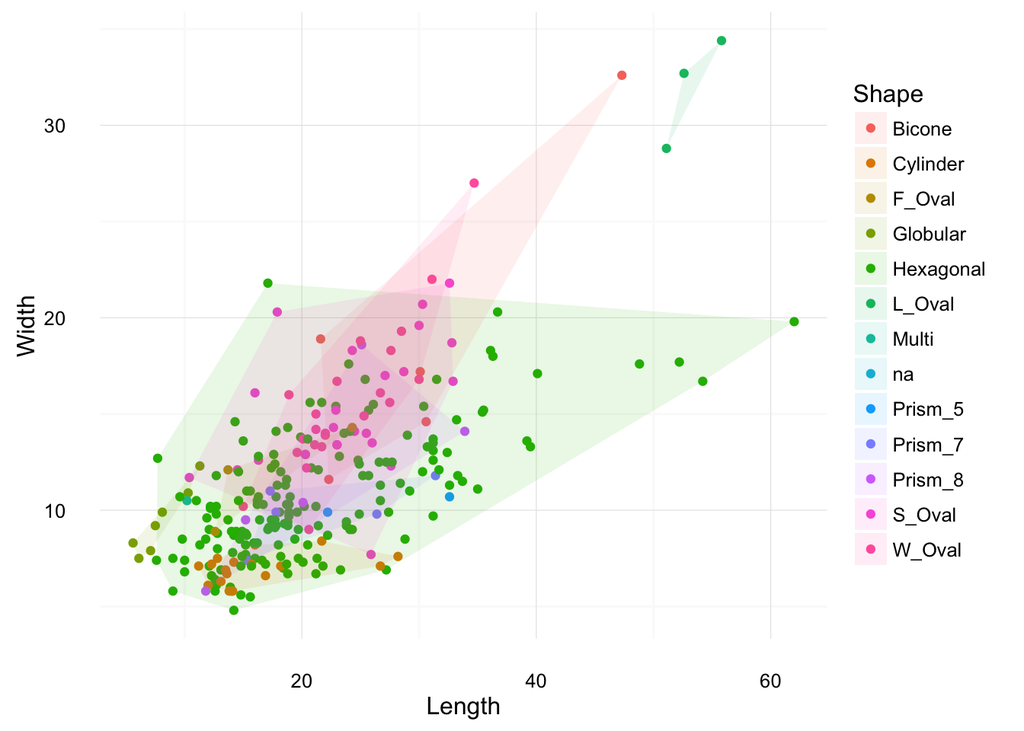

### Image of bead shape

For the bead image analysis, I only select beads from burial context, since the beads used as grave goods are relatively complete. The PCA analysis shows that over 90 percent of beads can be explained by three components. The first one is the variation of width, and the second and the third one show the shape from oval to rectangular. The k-mean analysis shows beads can be divided into three groups based on their shape, including rectangular, oval, and relatively globular.

#### PCA

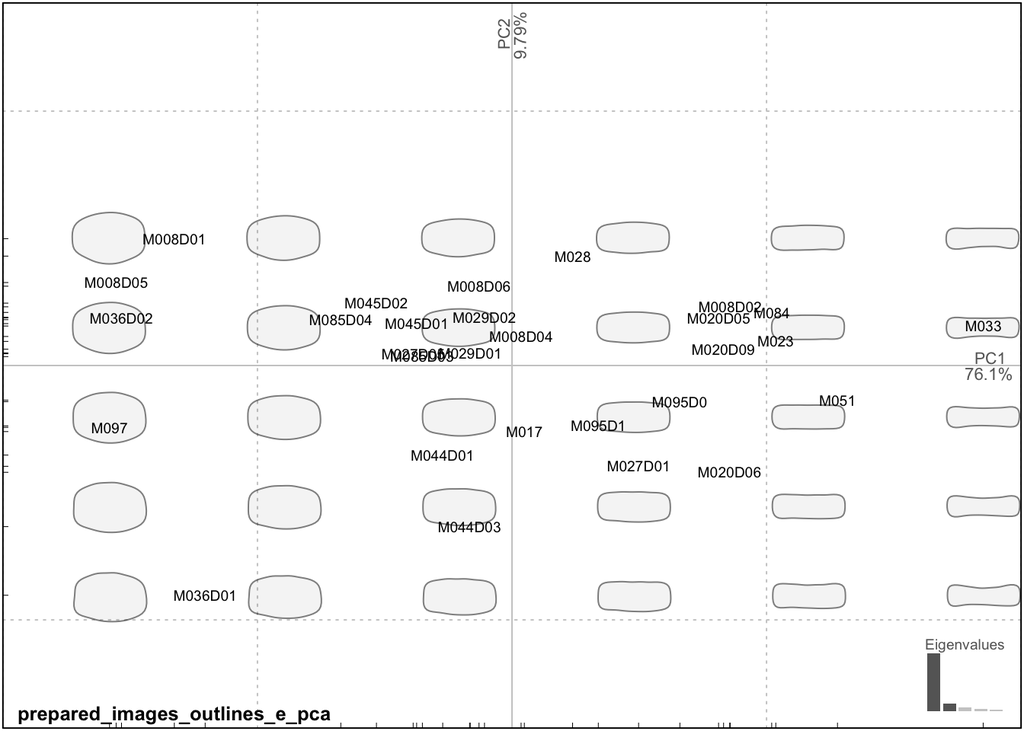

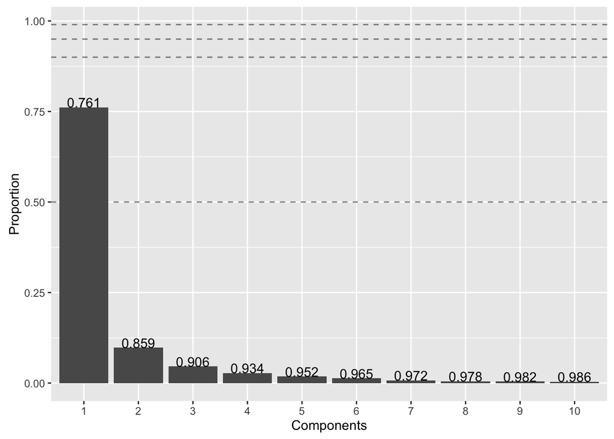

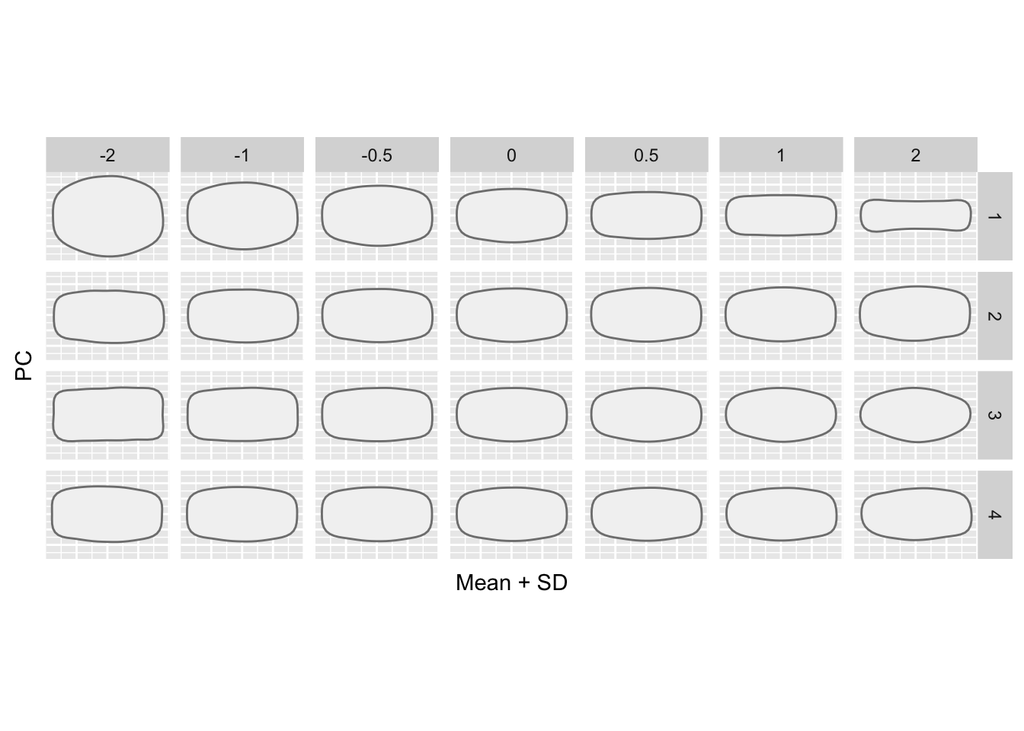

#### k means

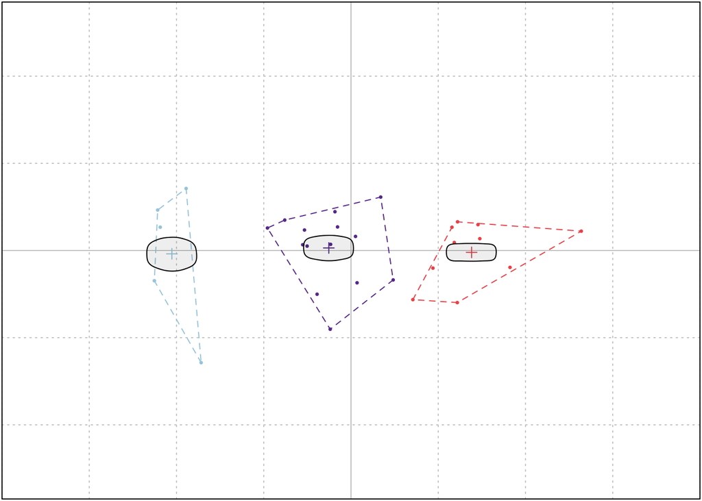

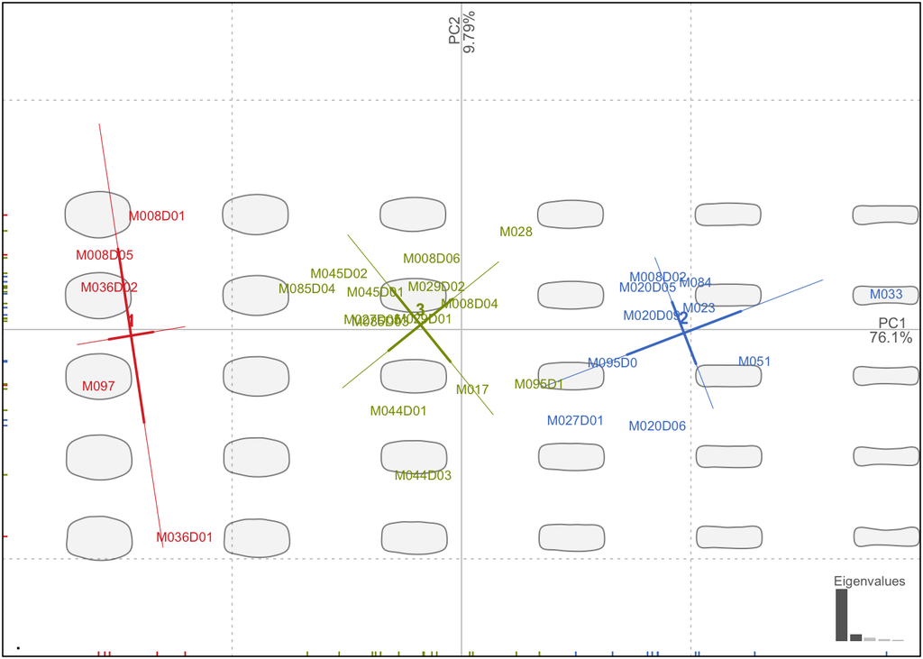

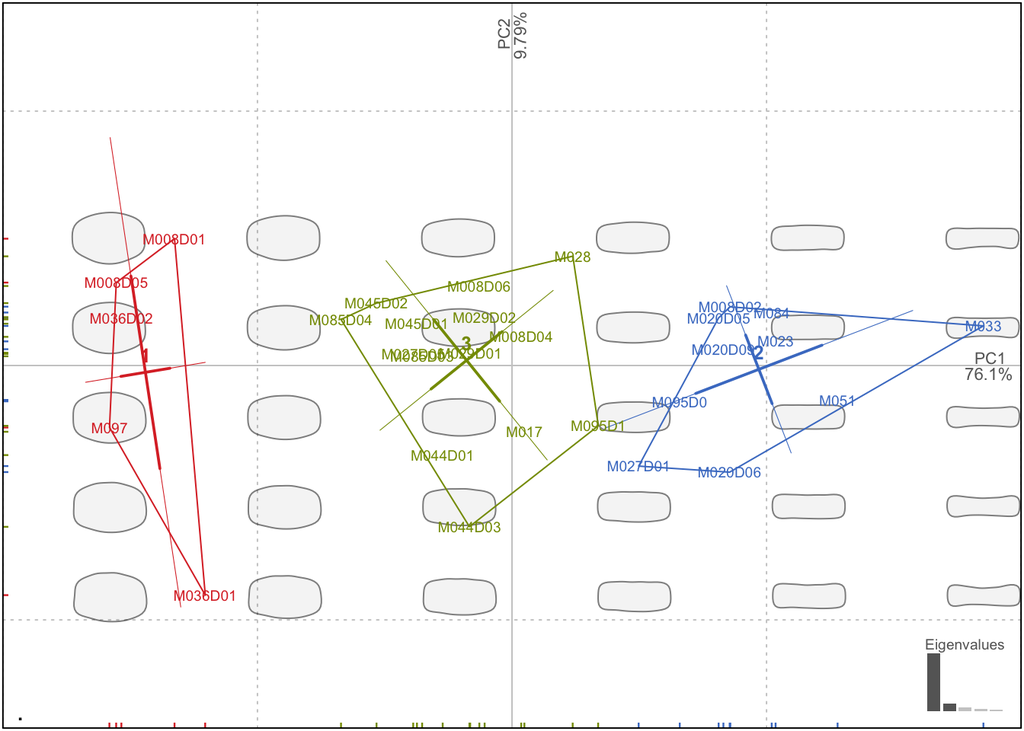